# Module 2: Data visualization I

PUBHLT0411: Statistical Packages for Public Health Data Analysis

Rebecca Deek, PhD

University of Pittsburgh, Biostatistics and Health Data Science

## Housekeeping/setup

```r
# the code below will load the necessary packages for these slides
# packages are normally loaded using library(packageName) after installing them.
# the `pacman` package has a function called `p_load` that checks if a package is
# installed. If it isn't installed, it will install it, otherwise it will load it.

# this line installs the pacman package, if you need it
if(!require(pacman)){
  install.packages(pacman)
  library(pacman)
}

pacman::p_load(countdown)
pacman::p_load(MASS)
pacman::p_load(tidyverse)

# data setup
data(birthwt)
```

## Graphics in R

- Summarizing data, numerically or graphically, is a critical part of data analysis.
- There are three main ways to visualize data in R:
  - Base R: Original built-in plotting system.
  - `ggplot2` package: Part of the tidyverse.
  - `lattice` package.
- We will primarily focus on `ggplot2` but start with an introduction to the base plotting functions.

## `birthwt` data

- The data are from the [MASS](https://www.rdocumentation.org/packages/MASS/versions/7.3-65/topics/birthwt) package and were collected at Baystate Medical Center, Springfield, Mass during 1986.

```r
str(birthwt)
```

```
'data.frame':   189 obs. of  10 variables:
 $ low  : int  0 0 0 0 0 0 0 0 0 0 ...
 $ age  : int  19 33 20 21 18 21 22 17 29 26 ...
 $ lwt  : int  182 155 105 108 107 124 118 103 123 113 ...
 $ race : int  2 3 1 1 1 3 1 3 1 1 ...
 $ smoke: int  0 0 1 1 1 0 0 0 1 1 ...
 $ ptl  : int  0 0 0 0 0 0 0 0 0 0 ...
 $ ht   : int  0 0 0 0 0 0 0 0 0 0 ...
 $ ui   : int  1 0 0 1 1 0 0 0 0 0 ...
 $ ftv  : int  0 3 1 2 0 0 1 1 1 0 ...
 $ bwt  : int  2523 2551 2557 2594 2600 2622 2637 2637 2663 2665 ...
```

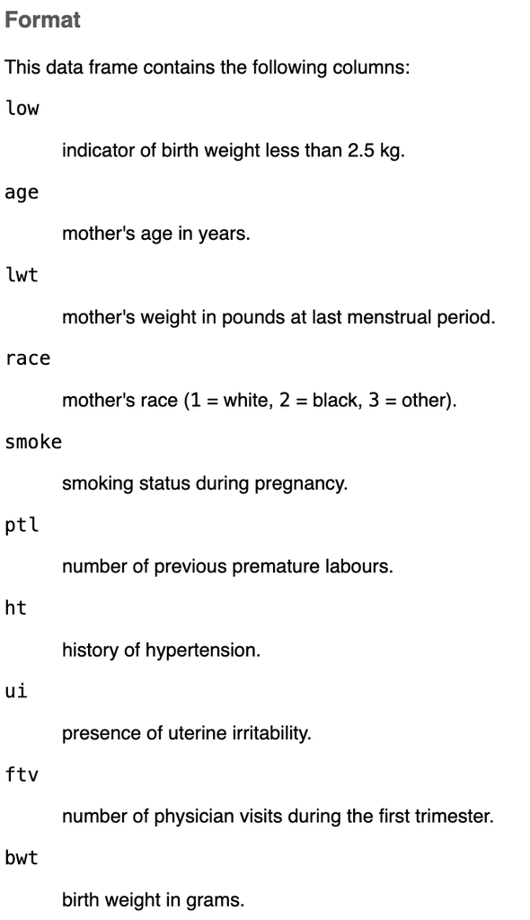

- We may be interested in understanding the distribution of variables (e.g., `age`, `bwt`) or how to variables are associated with one another (e.g., `lwt` and `bwt`).
  - Visualization can help with this.

## Base R: Scatterplots

- Examines the relationship between two numeric variables.

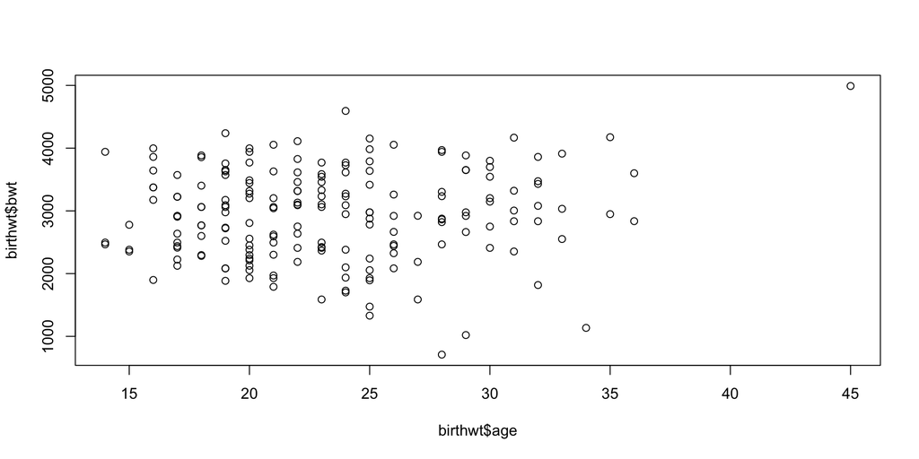

```r
plot(x = birthwt$age,
     y = birthwt$bwt)
```

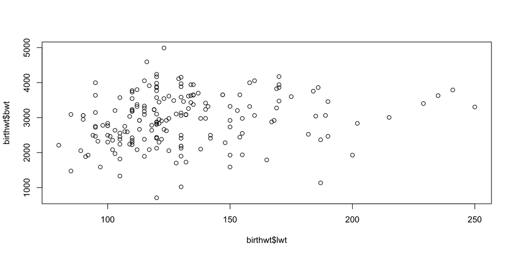

```r
# shorthand: y ~ x
plot(birthwt$bwt ~ birthwt$lwt)
```

- R has plotted *numeric* `bwt` on the y-axis and either *numeric* `age` or `lwt` on the x-axis.
- Must use `data$var` syntax, as there is no `data` argument.

```r
plot(x = bwt, y = age)
```

```
Error:
! object 'bwt' not found
```

## Base R: Histograms

- Graphical summary of the distribution of a numeric variable.
- Automatically creates the breakpoints (bins) in the histogram using the Sturges formula. Can be altered with `breaks` argument.

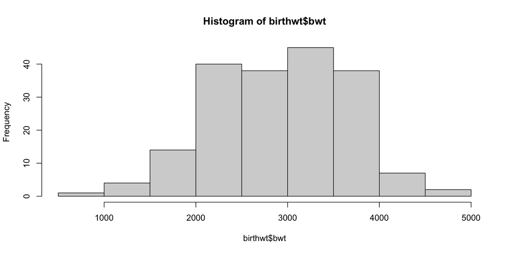

```r
hist(birthwt$bwt)
```

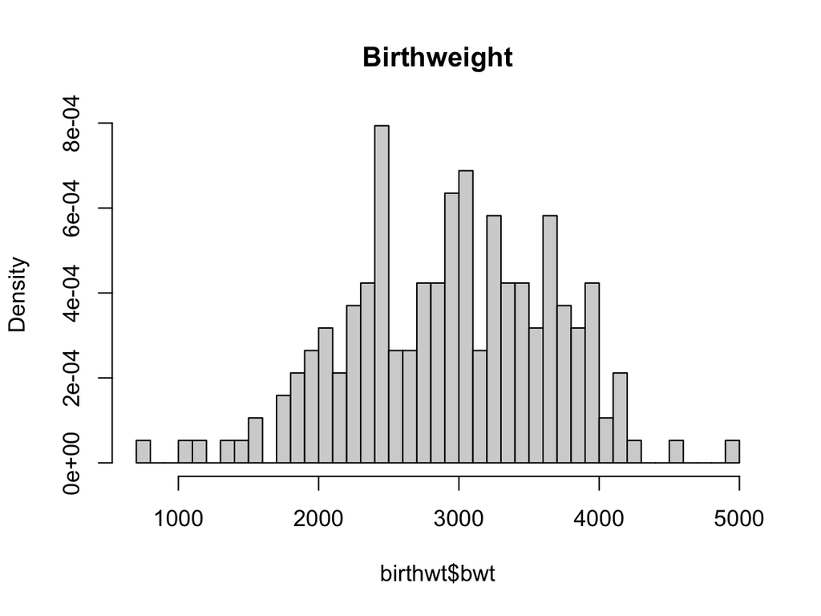

```r
hist(x = birthwt$bwt,
     breaks = seq(700,5000, 100),
     main = "Birthweight",
     freq = FALSE # density instead of counts
     )
```

## Base R: Histograms + density curve

- An estimated density curve can be added to proportion histograms.

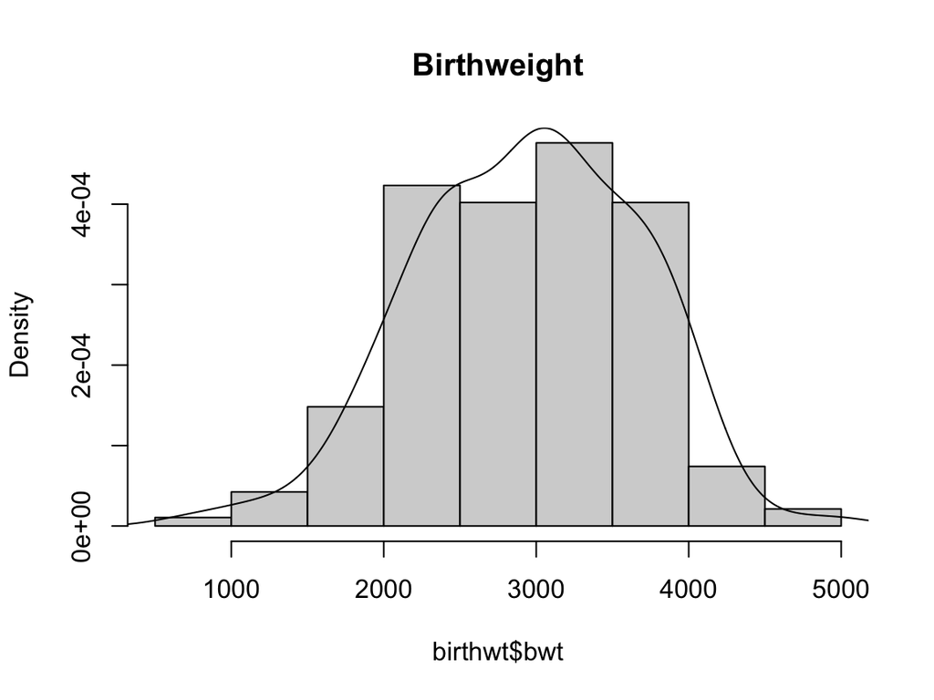

```r
dens.bw = density(birthwt$bwt) # calculate kernel density
hist(x = birthwt$bwt, main = "Birthweight", freq = FALSE)
lines(dens.bw) # add density as line
```

## Base R: Boxplot

- Graphical summary of the distribution of a numeric variable.
- Provide a measure of central tendency (the median value) and spread (IQR).

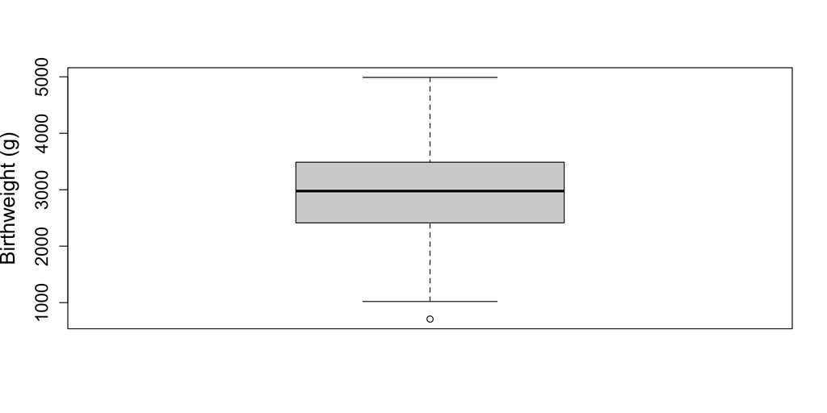

```r
boxplot(x = birthwt$bwt,
        ylab = "Birthweight (g)",
        cex.lab = 1.5, # larger label text
        cex.axis = 1.3 # larger axis text
        )
```

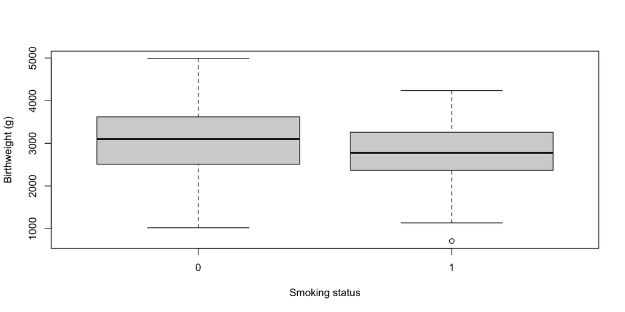

```r
boxplot(formula = bwt ~ smoke, # y ~ x
        data = birthwt,
        ylab = "Birthweight (g)",
        xlab = "Smoking status")
```

## Base R: Pairs plots

- `pairs()` helps visualize multiple scatterplots in one multipanel frame.

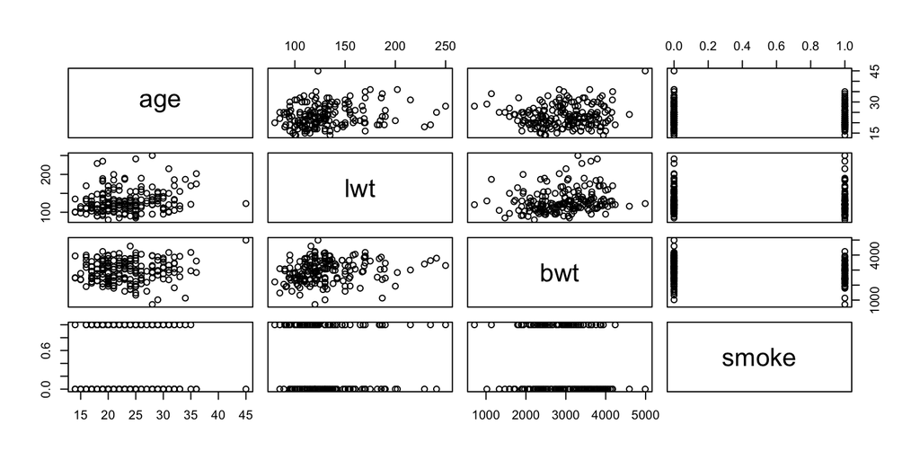

```r
pairs(birthwt[,c("age", "lwt", "bwt", "smoke")])
```

- Mostly helpful for pairs of continuous variables.

## Exercise: `Base R`

Create a boxplot of birthweight by race. First, set race (currently numeric 1, 2, 3) as a factor with labels. Title the boxplot “Boxplot of birthweight by race” and increase the font size of the x- and y-axis labels.

```
birthwt$race = (x = birthwt$race,  = 1:3,
                       = c("White", "Black", "Other"))

boxplot(bwt ~ race, data = ,
         = "Boxplot of birthweight by race",
        ylab = "Birthweight", xlab = "Race",
         = 1.5)
```

## Grammar of graphics and `ggplot2`

- `ggplot2` is an R package for producing statistical, or data, graphics.
- Has its own “grammar” based upon the Grammar of Graphics (Wilkinson, 2005).
  - [Short review](https://www.jstatsoft.org/article/view/v017b03).
- Graphs are created by combining independent components.
  - Create novel graphics that are tailored to your specific problem.

## Goal

- Create the following plot using `ggplot2` grammar.

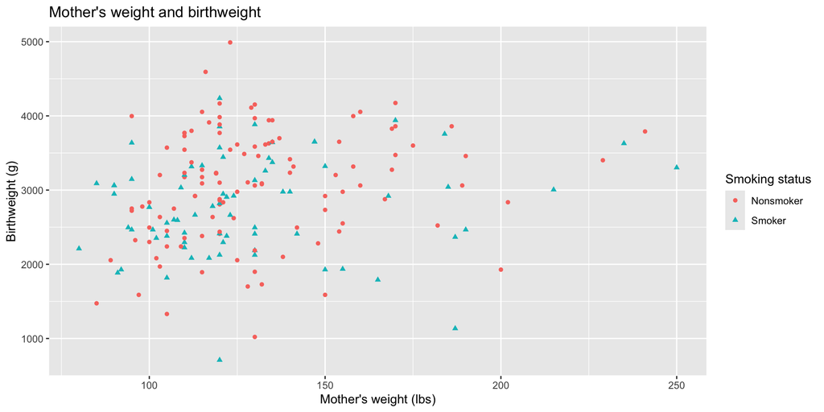

## First: Creating factors

```r
head(birthwt$smoke)
```

```
[1] 0 0 1 1 1 0
```

```r
birthwt$smoke = factor(birthwt$smoke,
                       levels = 0:1,
                       labels = c("Nonsmoker", "Smoker"))

head(birthwt$smoke)
```

```
[1] Nonsmoker Nonsmoker Smoker    Smoker    Smoker    Nonsmoker
Levels: Nonsmoker Smoker
```

## Text <–> Plot

> *Start with the `birthwt` data frame*

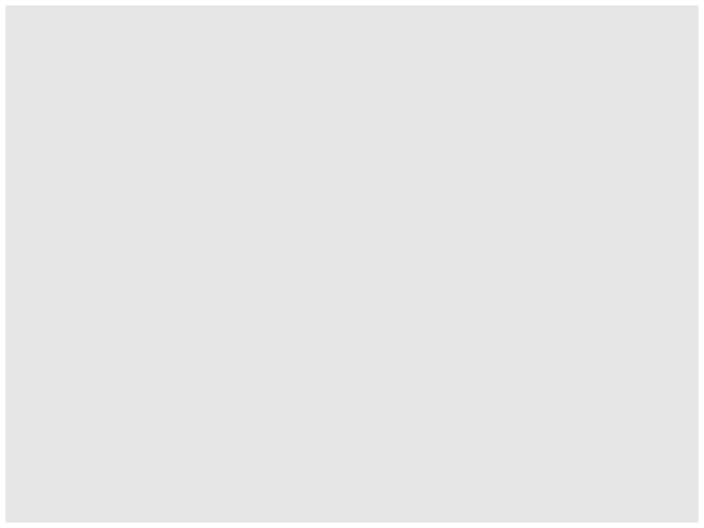

```r
ggplot2::ggplot(data = birthwt)
```

- All plots start with `ggplot()`. Defining a plot object that we will add layers to.
- Looks empty but is primed to plot `birthwt` data.

## Text <–> Plot

> Start with the `birthwt` data frame. *Map mother’s weight to the x-axis and birthweight to the y-axis.*

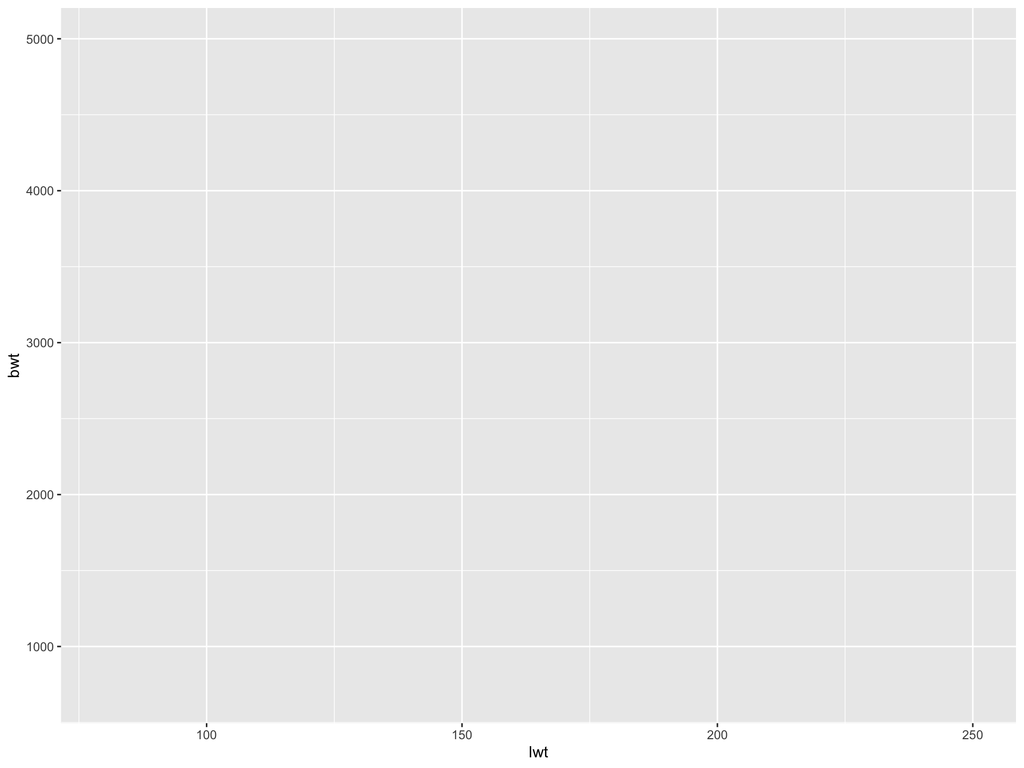

```r
ggplot2::ggplot(data = birthwt,
                mapping = aes(
                  x = lwt,
                  y = bwt)
                )
```

- Mappings are always defined in `aes()` [aesthetics] and define the visual properties of the plot.

## Text <–> Plot

> Start with the `birthwt` data frame. Map mother’s weight to the x-axis and birthweight to the y-axis. *Represent each observation with a point*

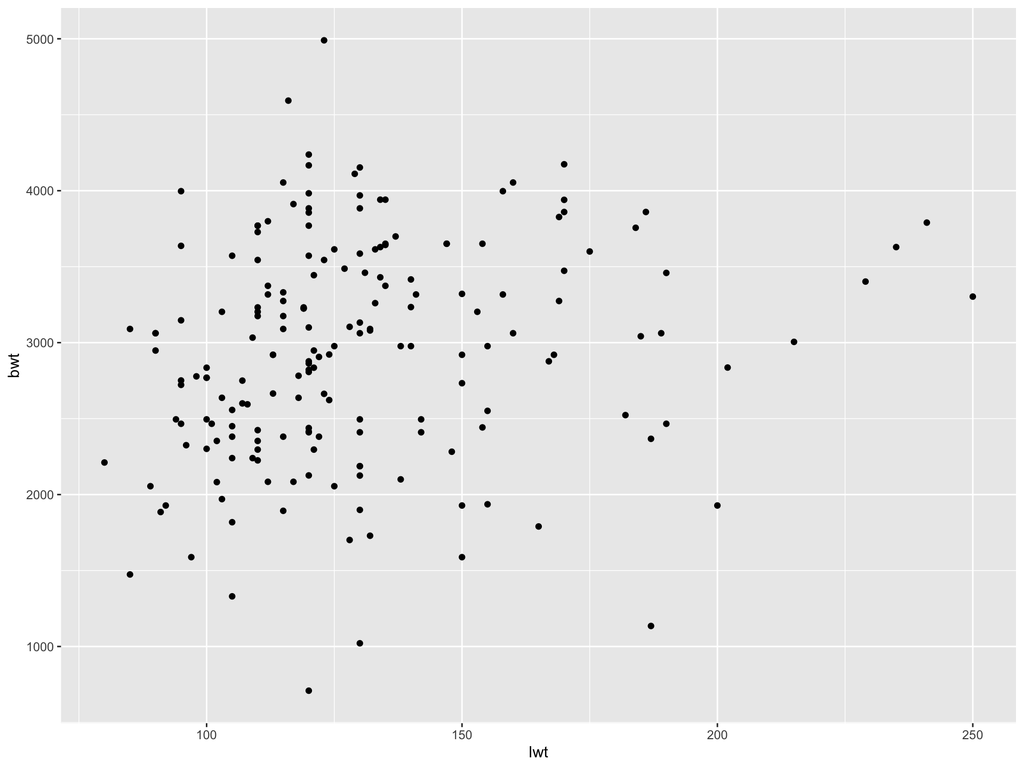

```r
ggplot2::ggplot(data = birthwt,
                mapping = aes(
                  x = lwt,
                  y = bwt)
                ) +
  ggplot2::geom_point()
```

- `geom_*()` plots the geometrical object that a represent data. Here we use points for a scatterplot.

## Text <–> Plot

> Start with the `birthwt` data frame. Map mother’s weight to the x-axis and birthweight to the y-axis. Represent each observation with a point. *Map smoking status to the color and shape of each point.*

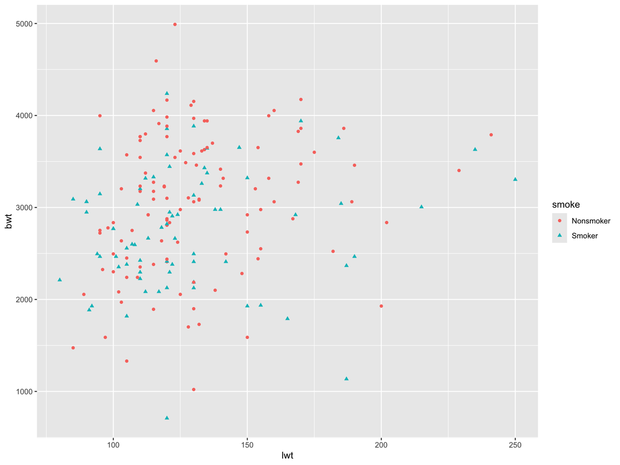

```r
ggplot2::ggplot(data = birthwt,
                mapping = aes(
                  x = lwt,
                  y = bwt)
                ) +
  ggplot2::geom_point(
    mapping = aes(color = smoke,
                  shape = smoke)
    )
```

- We are changing the aesthetics of the `geom_*` $\rightarrow$ use `aes()`.

## Text <–> Plot

> Start with the `birthwt` data frame. Map mother’s weight to the x-axis and birthweight to the y-axis. Represent each observation with a point. Map smoking status to the color and shape of each point. *Title the plot.*

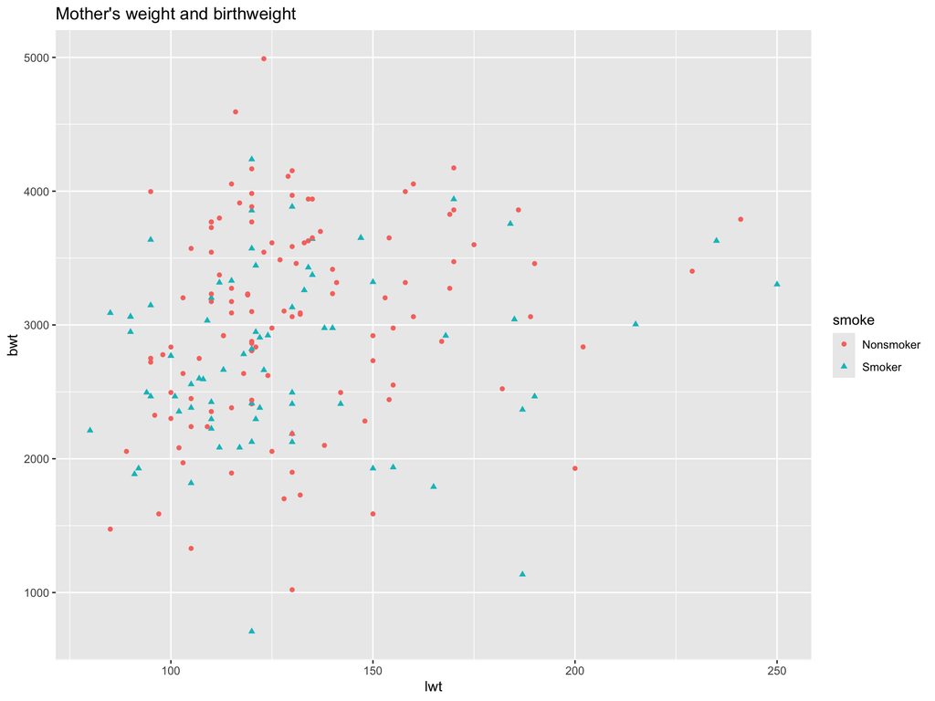

```r
ggplot2::ggplot(data = birthwt,
                mapping = aes(
                  x = lwt,
                  y = bwt)
                ) +
  ggplot2::geom_point(
    mapping = aes(color = smoke,
                  shape = smoke)
    ) +
  ggplot2::labs(
    title = "Mother's weight and birthweight"
  )
```

- `labs()` updates the labels of our plot.

## Text <–> Plot

> Start with the `birthwt` data frame. Map mother’s weight to the x-axis and birthweight to the y-axis. Represent each observation with a point. Map smoking status to the color and shape of each point. Title the plot. *Relabel the x- and y-axes.*

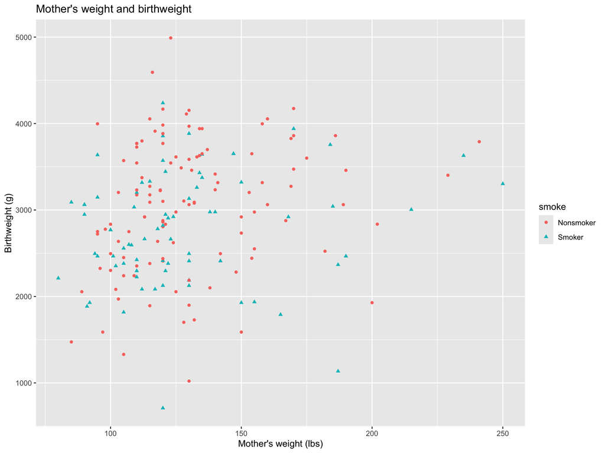

```r
ggplot2::ggplot(data = birthwt,
                mapping = aes(
                  x = lwt,
                  y = bwt)
                ) +
  ggplot2::geom_point(
    mapping = aes(color = smoke,
                  shape = smoke)
    ) +
  ggplot2::labs(
    title = "Mother's weight and birthweight",
    x = "Mother's weight (lbs)",
    y = "Birthweight (g)"
  )
```

## Text <–> Plot

> Start with the `birthwt` data frame. Map mother’s weight to the x-axis and birthweight to the y-axis. Represent each observation with a point. Map smoking status to the color and shape of each point. Title the plot. Relabel the x- and y-axes. *Relabel the legend title.*

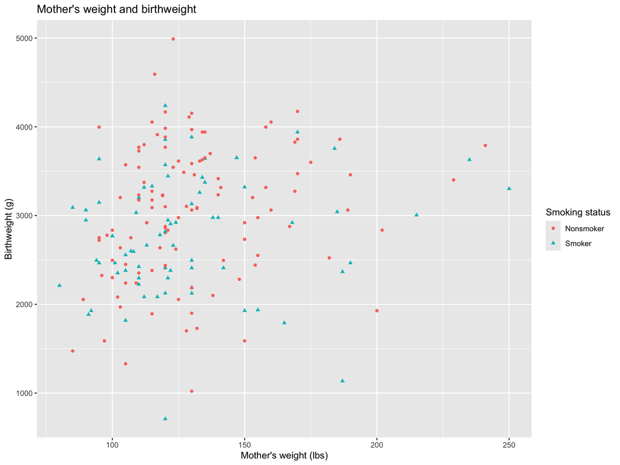

```r
ggplot2::ggplot(data = birthwt,
                mapping = aes(
                  x = lwt,
                  y = bwt)
                ) +
  ggplot2::geom_point(
    mapping = aes(color = smoke,
                  shape = smoke)
    ) +
  ggplot2::labs(
    title = "Mother's weight and birthweight",
    x = "Mother's weight (lbs)",
    y = "Birthweight (g)",
    color = "Smoking status",
    shape = "Smoking status"
  )
```

## `ggplot2` calls

- `ggplot()` has two main arguments: `data` and `mapping`.
- These names can be omitted and R will infer their assignments.
  - Helps to keep code concise and readable.
- We will learn about the pipe functions `%>%` and `|>` to streamline code.

```r
ggplot2::ggplot(
  data = birthwt,
  mapping = aes(x = lwt,
                y = bwt) ) +
  ggplot2::geom_point()
```

```r
ggplot2::ggplot( # lazy eval
  birthwt,
  aes(x = lwt,
      y = bwt) ) +
  ggplot2::geom_point()
```

```r
birthwt |> # piping
  ggplot2::ggplot(
    aes(x = lwt,
        y = bwt) ) +
  ggplot2::geom_point()
```

## Aesthetic options

Aesthetics are visual characteristics of the plotting geoms that can be *mapped to a specific variable in the data*.

Commonly used arguments are:

- `x`, `y` (position)
- `group` (group structure)
- `color`
- `fill`
- `shape`
- `size`
- `alpha` (transparency)
- `linetype`
- `linewidth`

## Mapping versus settings

- **Mapping:** determines visual properties (aesthetics) based on the *values of a variable in the data*.
  - Must be wrapped in `aes()` and passed into the `mapping` argument of `ggplot2()` or `geom_*()`.
- **Setting**: applies a *fixed, constant value,* not directly from the data, to visual properties of the plot.
  - Must be passed directly into `geom_*()` as an argument.
  - E.g., `size = 3`, `alpha = 0.8`, or `linetype = "dotted"`.

## Color and shape

- Both **mapped** to a *variable* $\rightarrow$ inside `aes()`.

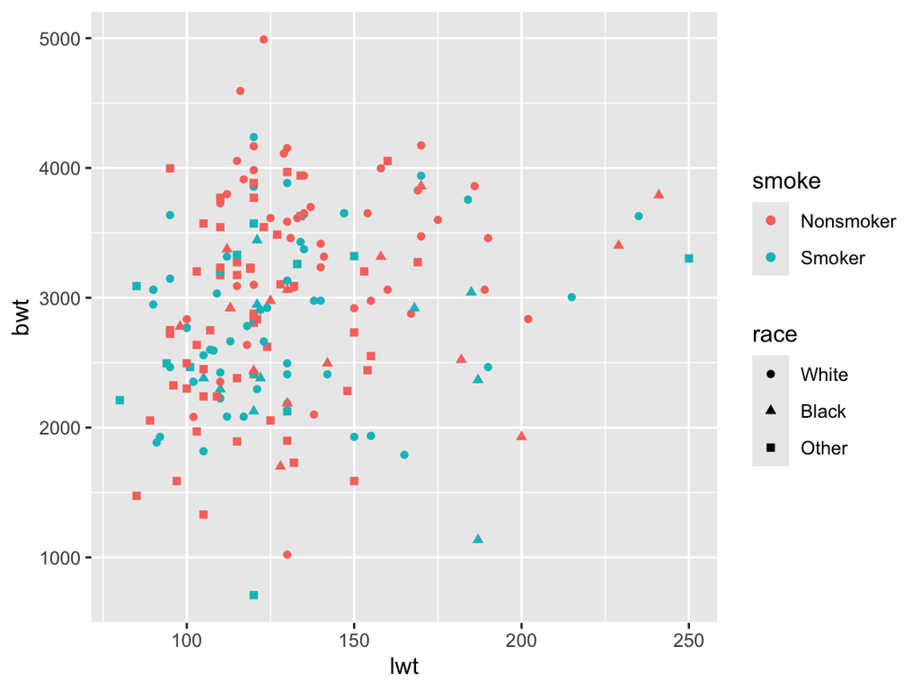

```r
ggplot2::ggplot(birthwt, aes(x = lwt, y = bwt) ) +
  ggplot2::geom_point(aes(color = smoke, shape = race))
```

## Size

- **Mapped** to a *variable* $\rightarrow$ inside `aes()`.

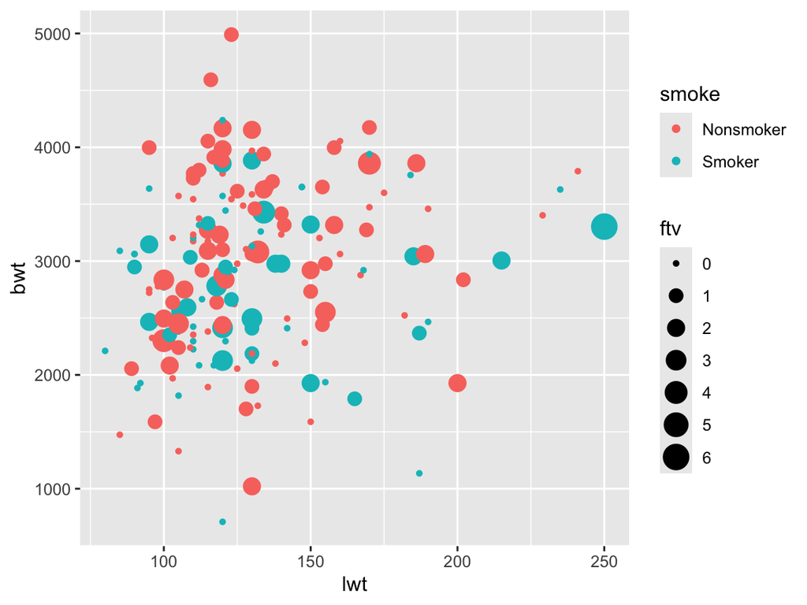

```r
ggplot2::ggplot(birthwt, aes(x = lwt, y = bwt) ) +
  ggplot2::geom_point(aes(color = smoke, size = ftv))
```

## Size

- **Set** to a *constant* $\rightarrow$ outside `aes()`.

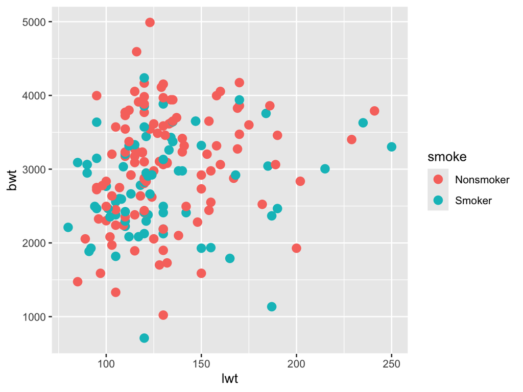

```r
ggplot2::ggplot(birthwt, aes(x = lwt, y = bwt) ) +
  ggplot2::geom_point(aes(color = smoke), size = 3)
```

## Alpha

- **Mapped** to a *variable* $\rightarrow$ inside `aes()`.

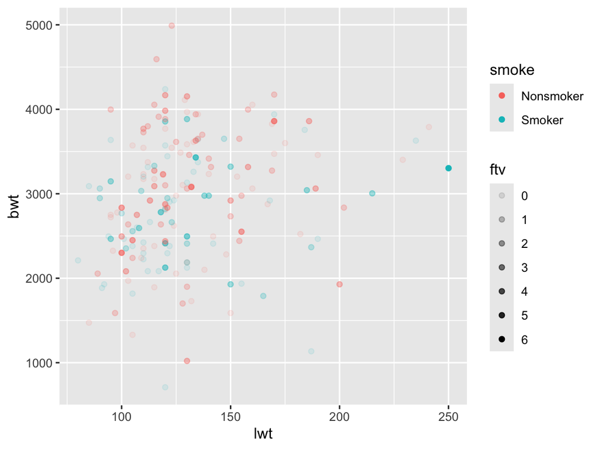

```r
ggplot2::ggplot(birthwt, aes(x = lwt, y = bwt) ) +
  ggplot2::geom_point(aes(color = smoke, alpha = ftv))
```

## Alpha

- **Set** to a *constant* (between 0 and 1) $\rightarrow$ outside `aes()`.

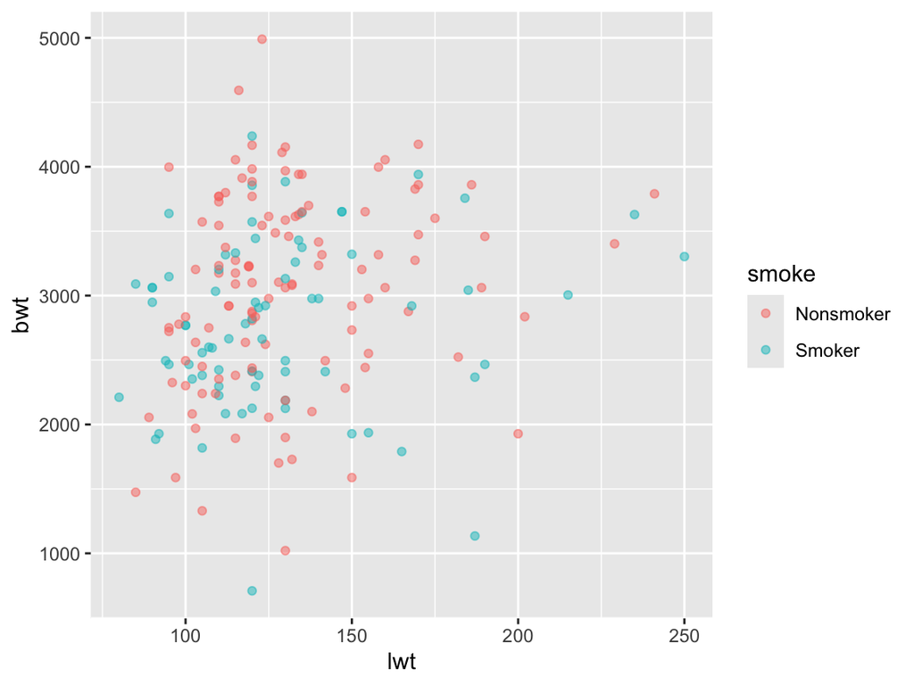

```r
ggplot2::ggplot(birthwt, aes(x = lwt, y = bwt) ) +
  ggplot2::geom_point(aes(color = smoke), alpha = 0.5)
```

## Linetype

- **Mapped** to a *variable* $\rightarrow$ inside `aes()`.

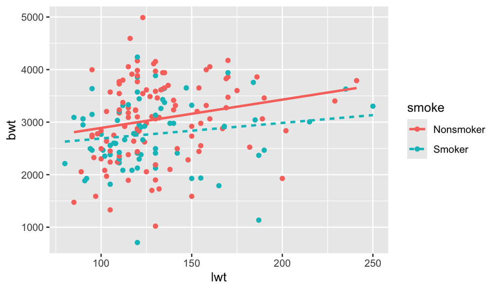

```r
ggplot2::ggplot(birthwt, aes(x = lwt, y = bwt) ) +
  ggplot2::geom_point(aes(color = smoke)) +
  ggplot2::geom_smooth(aes(color = smoke, linetype = smoke),
                       method = "lm", se = F)
```

Note: We have three mapping arguments, and some are redundant.

## Linetype

- **Set** to a [discrete *constant* or string](https://ggplot2.tidyverse.org/reference/aes_linetype_size_shape.html#linetype) $\rightarrow$ outside `aes()`.

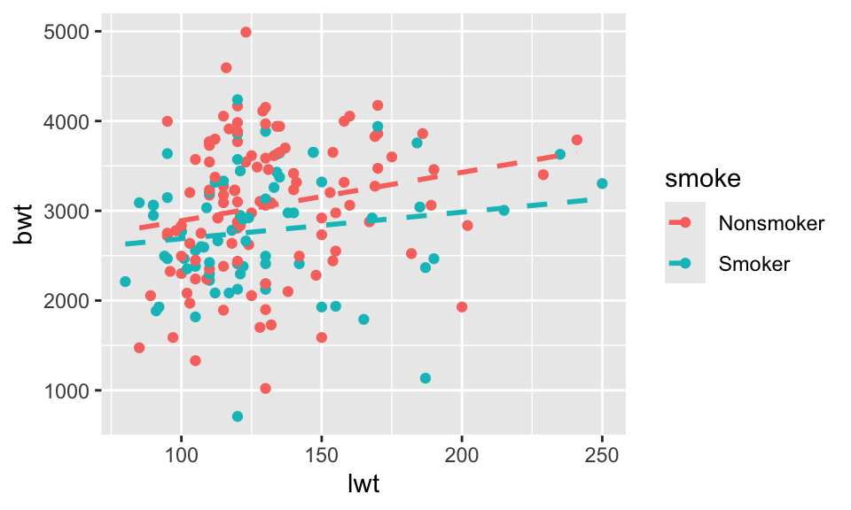

```r
ggplot2::ggplot(birthwt, aes(x = lwt, y = bwt,
                             color = smoke) ) +
  ggplot2::geom_point() +
  geom_smooth(linetype = 2,
              method = "lm", se = F)
```

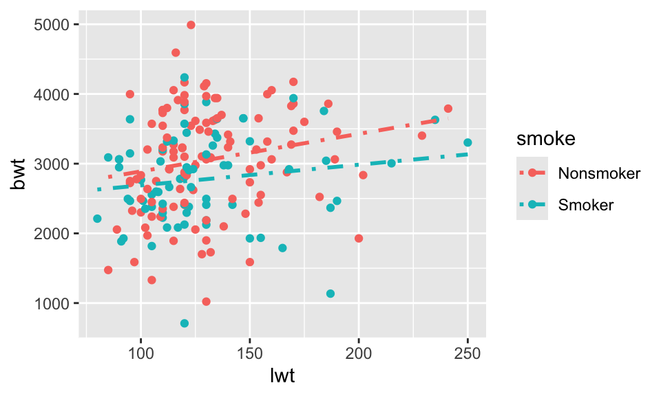

```r
ggplot2::ggplot(birthwt, aes(x = lwt, y = bwt,
                             color = smoke) ) +
  ggplot2::geom_point() +
  geom_smooth(linetype = "dotdash",
              method = "lm", se = F)
```

Note: Mappings were condensed.

## Linewidth

- **Set** to a constant $\rightarrow$ outside `aes()`.

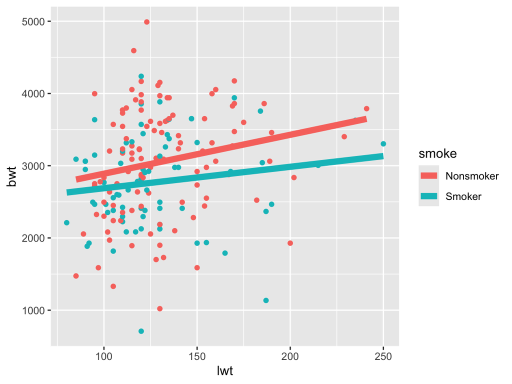

```r
ggplot2::ggplot(birthwt, aes(x = lwt, y = bwt) ) +
  ggplot2::geom_point(aes(color = smoke)) +
  ggplot2::geom_smooth(aes(color = smoke), linewidth = 2.5,
                       method = "lm", se = F)
```

## Note on aesthetic options

Available aesthetics depend on the `geom` used. See [help files](https://ggplot2.tidyverse.org/reference/index.html#Geoms).

- E.g., `linewidth` or `linetype` would work for geoms with lines (e.g., `geom_bar`, `geom_histogram`, `geom_boxplot`) but not for geoms with points (e.g., `geom_point`).
- Supplying a discrete variable for `alpha` or `size` doesn’t make sense.

```r
ggplot2::ggplot(birthwt, aes(x = lwt, y = bwt) ) +
  ggplot2::geom_point(aes(alpha = smoke), linewidth = 2)
```

- Likewise for a continuous variable and `shape`.

## Default aesthetics

Once you map an aesthetic, `ggplot2` takes care of the rest. It:

- Selects a reasonable scale to use with the aesthetic.
- Constructs a legend that explains the mapping between levels and values.
- For `x` and `y` aesthetics, no legend is created. Instead an axis line with tick marks and a label is made.

These are the *default options* provided by `ggplot2`, there are functions and arguments to override them.

- Our main example showed how `labs()` over rides axis and legend labels. We will go over other ways to make changes to axes, labels, and legends.

## Visualizing data and distributions

- How you visualize data depends on multiple considerations.
  - Is the data categorical (characters or factors) or numerical (double or integer)?
  - Do you want to visualize one variable or the relationship between two or more variables?
- The answer to these questions will determine:
  - Which `geom_*()` to use.
  - The inputs into the aesthetic mappings `aes()`.

## `geom_bar()`: One variable

- Single categorical variable.
- The height of the bars displays how many observations occurred for each `x` value.

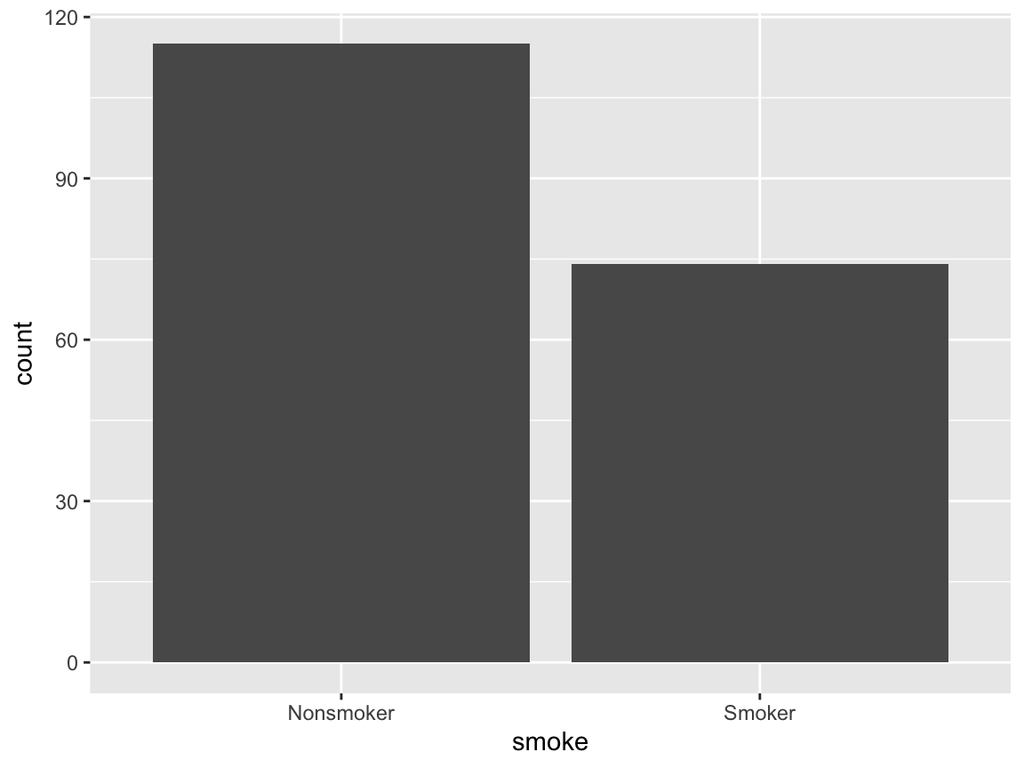

```r
ggplot2::ggplot(birthwt, aes(x = smoke)) +
  ggplot2::geom_bar()
```

## `geom_bar()`: Two variables

- Two categorical variables.
- Can create either frequency or relative frequency plots.

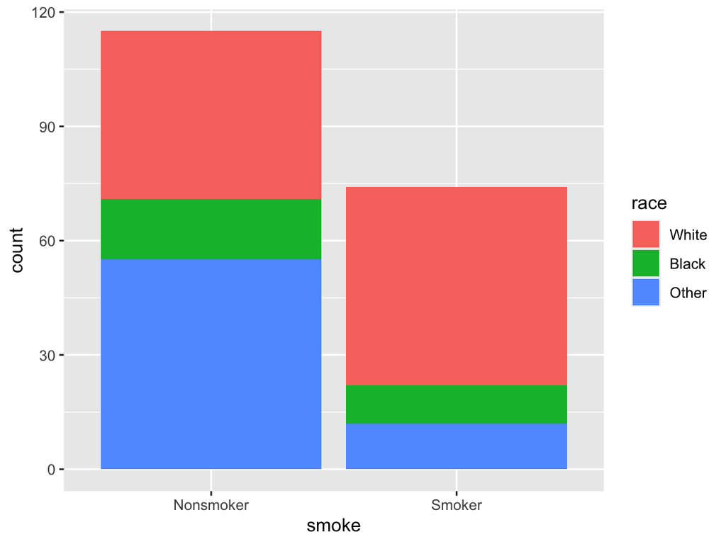

```r
ggplot2::ggplot(birthwt,
                aes(x = smoke,
                    fill = race) ) +
  ggplot2::geom_bar()
```

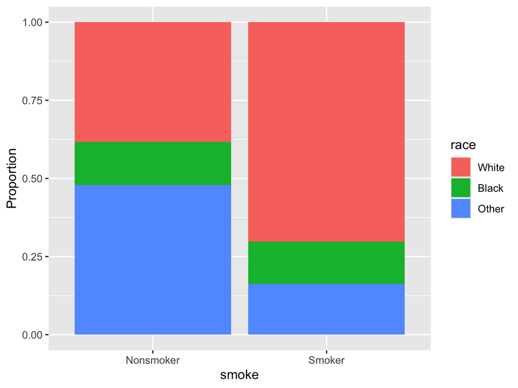

```r
ggplot2::ggplot(birthwt,
                aes(x = smoke,
                    fill = race) ) +
  ggplot2::geom_bar(position = "fill") + # rel freq
  ggplot2::labs(y = "Proportion")
```

## Exercise: `ggplot2`

Create a scatterplot of age (x) vs birthweight (y). Color the points by presence of uterine irritability (`ui`). Is this plot how you expected?

```
ggplot2::ggplot(birthwt, aes(x = , y = ) ) +
  ggplot2::geom_point(( = ui))
```

Change the value of the shape argument and see how the plot changes. Try both numbers and strings (of common shapes). Why do all points change shape?

```
ggplot2::ggplot(birthwt, aes(x = age, y = bwt) ) +
  ggplot2::geom_point(shape = )
```